# PYTHON FOR DATA ANALYSIS S220 COURSE OUTLINE

## 1. 2. 3. DESCRIPTIVE ANALYSIS Python essentials - Pandas - Matplotlib - Seaborn - Geopandas - Know your dataset

## 4. Webscraping

## 5.6.7.8. PREDICTIVE ANALYSIS

## 9. Releasing your work : API with Flask / Django

# 1. Four Python important concepts

( Many parts of this chapter are cut/paste of Romain Jouin Notebooks)

## 1.1 comprehension list

```python
import random
n     = 10
```

### construction 'classique' de liste dans une boucle for

```python
une_chaine_de_caractere = "dsfghjklmsdfghjkldfghjklfdghjkl"
liste = []
for _ in range(n):
    caractere = random.choice(une_chaine_de_caractere)
    liste.append(caractere)
```

```python
liste
```

```
['m', 'h', 'h', 'h', 's', 's', 'f', 'h', 'j', 'f']
```

Please note the *UNDERSCORE VARIABLE* used in the for loops. it's just like any other variable name. think about it as a trashaway variable

### construction 'moderne' de liste via une comprehension list

```python
# [f(x) for x in sequence]

liste2 = [random.choice(une_chaine_de_caractere) for _ in range(n)]
liste2
```

```
['f', 'g', 'd', 'g', 'h', 'd', 'f', 'd', 'm', 'h']
```

```python
liste2 = ["e" for _ in range(n)]
liste2
```

```
['e', 'e', 'e', 'e', 'e', 'e', 'e', 'e', 'e', 'e']
```

### multiplication de listes

```python
liste2 = ["e"] * 10
liste2
```

```
['e', 'e', 'e', 'e', 'e', 'e', 'e', 'e', 'e', 'e']
```

### comprehension list conditionelle : if only => le if est à la fin

```python
# [f(x) for x in sequence if condition]


liste2 = [ _ for _ in range(n) if _%2==0]
liste2
```

```
[0, 2, 4, 6, 8]
```

### comprehension list conditionelle : if else => le if est au milieu

```python
# [f(x) if condition else g(x) for x in sequence]

liste2 = [ _ if _%2==0 else "impair" for _ in range(n) ]
liste2
```

```
[0, 'impair', 2, 'impair', 4, 'impair', 6, 'impair', 8, 'impair']
```

```python
# EQUIVAUT A

liste2=[]
def pairouimpair(x):
    if x%2==0:
        return x
    else:
        return "impair"
for i in range(n):
    liste2.append(pairouimpair(i))
liste2
```

```
[0, 'impair', 2, 'impair', 4, 'impair', 6, 'impair', 8, 'impair']
```

```python
liste2 = [ _ if _%2  else "pair" for _ in range(n) ]
liste2
```

```
['pair', 1, 'pair', 3, 'pair', 5, 'pair', 7, 'pair', 9]
```

```python
# Notez bien dans la cellule précédente le if _%2
# Qui équivaut à if _%2 != 0
# Car en python, tout ce qui n'est pas 0 est vrai
# Vérifions le :

if 0:
    print("0 est vrai")
else:
    print("0 est faux")
```

```
0 est faux
```

```python
if 1:
    print("1 est vrai")
else:
    print("1 est faux")
```

```
1 est vrai
```

```python
if "mldkfmslk":
    print("mldkfmslk est vrai")
else:
    print("mldkfmslk est faux")
```

```
mldkfmslk est vrai
```

## 1.2 lambda functions

```python
# valeur = lambda x:f(x)
valeur  = lambda param : param
```

```python
valeur("e")
```

```
'e'
```

```python
deux_fois  = lambda param : param*2
deux_fois("e")
```

```
'ee'
```

```python
# SAME THING AS
def deux_fois(x):
    return x*2

deux_fois("e")
```

```
'ee'
```

```python
deux_fois  = lambda param : param*2
```

```python
# Si le paramètre est une liste, la fonction renvoie une liste
deux_fois(["e"])
```

```
['e', 'e']
```

```python
deux_fois(deux_fois(["e"]))
```

```
['e', 'e', 'e', 'e']
```

```python
deux_fois(["1", "2"])
```

```
['1', '2', '1', '2']
```

```python
# LAMBDA DEFINED FUNCTION + LIST COMPREHENSION
zero_dixhuit = [deux_fois(_) for _ in range(10)]
zero_dixhuit
```

```
[0, 2, 4, 6, 8, 10, 12, 14, 16, 18]
```

### 1.3 Function calls : named parameters VS standard ordered parameters

```python
# DEFINE A FUNCTION
def asurb(a,b):
    return a/b

# Calling a function using ORDERERD PARAMETERS
# We must input the parameters in the same order used in function definition
asurb(10,2)
```

```
5.0
```

```python
# Calling a function using NAMED (aka Kewords) PARAMETERS
# Order don't matter anymore
asurb(b=10,a=20)
```

```
2.0
```

```python
# If we didn't gave default values for a parameter, we must transmit it when calling the function
asurb(b=10)
```

```
---------------------------------------------------------------------------
TypeError                                 Traceback (most recent call last)
<ipython-input-25-a40928b154e9> in <module>
      1 # If we didn't gave default values for a parameter, we must transmit it when calling the function
----> 2 asurb(b=10)

TypeError: asurb() missing 1 required positional argument: 'a'
```

```python
# DEFINE A FUNCTION  with DEFAULT VALUES
def asurb(a=10,b=5):
    return a/b
```

```python
asurb(b=10)
```

```
1.0
```

```python
asurb()
```

```
2.0
```

## 1.4 transmitting arbitrary named parameters to a function

```python
# FIRST LET'S CREATE A RANDOM DATAFRAME

import random
import pandas as pd
eleves=['William','Hugh','Marvin','Stella','Serge','Kimiko']
# LIST COMPREHENSION
liste_eleves = [random.choice(eleves) for _ in range(60)]

# as we saw before, this is EQUIVALENT TO
# liste_eleves=[]
# for _ in range(60):
#    liste_eleves.append(random.choice(eleves))

def note():
    return(random.randint(1,20))

notes = [ note() for _ in range(60)]

eleves_notes = pd.DataFrame()
eleves_notes['eleve']=liste_eleves
eleves_notes['note']=notes
eleves_notes
```

|  | eleve | note |
| --- | --- | --- |
| 0 | Stella | 9 |
| 1 | Stella | 18 |
| 2 | Serge | 4 |
| 3 | William | 14 |
| 4 | Serge | 18 |
| 5 | Stella | 13 |
| 6 | Marvin | 4 |
| 7 | Marvin | 12 |
| 8 | Kimiko | 9 |
| 9 | William | 20 |
| 10 | Stella | 9 |
| 11 | William | 12 |
| 12 | Kimiko | 8 |
| 13 | William | 11 |
| 14 | Stella | 16 |
| 15 | Marvin | 16 |
| 16 | Serge | 10 |
| 17 | Stella | 15 |
| 18 | Hugh | 12 |
| 19 | Marvin | 4 |
| 20 | Marvin | 12 |
| 21 | Serge | 17 |
| 22 | Serge | 12 |
| 23 | Marvin | 12 |
| 24 | Hugh | 17 |
| 25 | Serge | 11 |
| 26 | Stella | 14 |
| 27 | Kimiko | 2 |
| 28 | William | 13 |
| 29 | Stella | 9 |
| 30 | William | 8 |
| 31 | Marvin | 14 |
| 32 | Stella | 20 |
| 33 | Kimiko | 19 |
| 34 | Serge | 8 |
| 35 | William | 15 |
| 36 | Hugh | 5 |
| 37 | William | 2 |
| 38 | Hugh | 7 |
| 39 | William | 18 |
| 40 | Serge | 12 |
| 41 | Hugh | 9 |
| 42 | William | 14 |
| 43 | Serge | 9 |
| 44 | Kimiko | 12 |
| 45 | Serge | 2 |
| 46 | Stella | 7 |
| 47 | Serge | 4 |
| 48 | Kimiko | 10 |
| 49 | Marvin | 12 |
| 50 | Hugh | 3 |
| 51 | Serge | 3 |
| 52 | Hugh | 18 |
| 53 | Kimiko | 12 |
| 54 | Serge | 9 |
| 55 | William | 3 |
| 56 | Hugh | 4 |
| 57 | William | 20 |
| 58 | William | 17 |
| 59 | William | 20 |

```python
# Like we did last TP, let's create a function to extract the best 5 grades for each student

def get_top5(df):
    return df.sort_values(by="note")[-5:]

# rank here is static, it cannot be transmitted during the function call

eleves_notes.groupby(['eleve']).apply(get_top5)
```

| eleve |  | eleve | note |
| --- | --- | --- | --- |
| Hugh | 38 | Hugh | 7 |
|  | 41 | Hugh | 9 |
|  | 18 | Hugh | 12 |
|  | 24 | Hugh | 17 |
|  | 52 | Hugh | 18 |
| Kimiko | 8 | Kimiko | 9 |
|  | 48 | Kimiko | 10 |
|  | 44 | Kimiko | 12 |
|  | 53 | Kimiko | 12 |
|  | 33 | Kimiko | 19 |
| Marvin | 20 | Marvin | 12 |
|  | 23 | Marvin | 12 |
|  | 49 | Marvin | 12 |
|  | 31 | Marvin | 14 |
|  | 15 | Marvin | 16 |
| Serge | 25 | Serge | 11 |
|  | 22 | Serge | 12 |
|  | 40 | Serge | 12 |
|  | 21 | Serge | 17 |
|  | 4 | Serge | 18 |
| Stella | 26 | Stella | 14 |
|  | 17 | Stella | 15 |
|  | 14 | Stella | 16 |
|  | 1 | Stella | 18 |
|  | 32 | Stella | 20 |
| William | 58 | William | 17 |
|  | 39 | William | 18 |
|  | 9 | William | 20 |
|  | 57 | William | 20 |
|  | 59 | William | 20 |

it works, but what if we want to make this function dynamic and transmit the rank as a parameter so that we can use it to ask top 5 , top 10 or top 1000 without having to rewrite it ?

### Transmitting rank as parameter when using pandas groupby apply()

Let's look at Pandas Apply function definition from the doc :

**kwds mean that we can add an arbitrary list of kewords (named) parameters that will be transmitted to the applied function

**is a packing operator. it will pack the arbitrary list of** named parameters ** into a single python dict, where parameters name will become dict keys

```python
# During last TP, a student proposed this method :
# **kwags will create a dict with all the named parameters

def get_top(df,**kwags):
    return df.sort_values(by="note")[-kwags['top']:]

eleves_notes.groupby(['eleve']).apply(get_top,top=5)
```

| eleve |  | eleve | note |
| --- | --- | --- | --- |
| Hugh | 38 | Hugh | 7 |
|  | 41 | Hugh | 9 |
|  | 18 | Hugh | 12 |
|  | 24 | Hugh | 17 |
|  | 52 | Hugh | 18 |
| Kimiko | 8 | Kimiko | 9 |
|  | 48 | Kimiko | 10 |
|  | 44 | Kimiko | 12 |
|  | 53 | Kimiko | 12 |
|  | 33 | Kimiko | 19 |
| Marvin | 20 | Marvin | 12 |
|  | 23 | Marvin | 12 |
|  | 49 | Marvin | 12 |
|  | 31 | Marvin | 14 |
|  | 15 | Marvin | 16 |
| Serge | 25 | Serge | 11 |
|  | 22 | Serge | 12 |
|  | 40 | Serge | 12 |
|  | 21 | Serge | 17 |
|  | 4 | Serge | 18 |
| Stella | 26 | Stella | 14 |
|  | 17 | Stella | 15 |
|  | 14 | Stella | 16 |
|  | 1 | Stella | 18 |
|  | 32 | Stella | 20 |
| William | 58 | William | 17 |
|  | 39 | William | 18 |
|  | 9 | William | 20 |
|  | 57 | William | 20 |
|  | 59 | William | 20 |

```python
# please note that kwags name is not mandatory
# the only mandatory element is the double * (splats) for "packing"
# Here we add the sort column name as a parameter.

def get_top(df,**mondicoamoi):
    return df.sort_values(by=mondicoamoi['sort'])[-mondicoamoi['top']:]

eleves_notes.groupby(['eleve']).apply(get_top,sort="note",top=3)
```

[output not shown]

```python
# But we can do more simple ( and add sort column as parameter) :

def get_top(df,top,sort):
    return df.sort_values(by=sort)[-top:]

eleves_notes.groupby(['eleve']).apply(get_top,sort="note",top=2)
```

| eleve |  | eleve | note |
| --- | --- | --- | --- |
| Hugh | 24 | Hugh | 17 |
|  | 52 | Hugh | 18 |
| Kimiko | 53 | Kimiko | 12 |
|  | 33 | Kimiko | 19 |
| Marvin | 31 | Marvin | 14 |
|  | 15 | Marvin | 16 |
| Serge | 21 | Serge | 17 |
|  | 4 | Serge | 18 |
| Stella | 1 | Stella | 18 |
|  | 32 | Stella | 20 |
| William | 57 | William | 20 |
|  | 59 | William | 20 |

```python
# And give default values

def get_top(df,top=10,sort='note'):
    return df.sort_values(by=sort)[-top:]

eleves_notes.groupby(['eleve']).apply(get_top,top=2)
```

| eleve |  | eleve | note |
| --- | --- | --- | --- |
| Hugh | 24 | Hugh | 17 |
|  | 52 | Hugh | 18 |
| Kimiko | 53 | Kimiko | 12 |
|  | 33 | Kimiko | 19 |
| Marvin | 31 | Marvin | 14 |
|  | 15 | Marvin | 16 |
| Serge | 21 | Serge | 17 |
|  | 4 | Serge | 18 |
| Stella | 1 | Stella | 18 |
|  | 32 | Stella | 20 |
| William | 57 | William | 20 |
|  | 59 | William | 20 |

Pour en savoir plus

packing / unpacking : https://deusyss.developpez.com/tutoriels/Python/args_kwargs/

et

keyword parameters : https://treyhunner.com/2018/04/keyword-arguments-in-python/

# 2. CHOROPLETH MAP USING GEOPANDAS

A choropleth map (from Greek χῶρος "area/region" and πλῆθος "multitude") is a type of thematic map in which areas are shaded or patterned in proportion to a statistical variable that represents an aggregate summary of a geographic characteristic within each area, such as population density or per-capita income.

https://fr.wikipedia.org/wiki/Carte_choropl%C3%A8the

```python
!pip3 install geopandas
```

[output not shown]

```python
!pip install geopandas
# IF it does not work on your side, i suggest you use google colab, or a docker container
```

[output not shown]

```python
import sys
path = fr"{str(sys.executable)}"
get_ipython().system('"{path}" -m pip install geopandas --user')
```

```python
# GOOGLE SEARCH gis boundaries french departments
# https://www.data.gouv.fr/fr/datasets/r/ab21d892-aa39-466a-a3ed-dc25ff076b78
# Example from https://towardsdatascience.com/lets-make-a-map-using-geopandas-pandas-and-matplotlib-to-make-a-chloropleth-map-dddc31c1983d


import geopandas as gpd
map_df = gpd.read_file("datasets/departements-20140306-50m-shp/departements-20140306-50m.shp")
map_df
```

|  | code_insee | nom | nuts3 | wikipedia | geometry |
| --- | --- | --- | --- | --- | --- |
| 0 | 01 | Ain | FR711 | b'fr:Ain (d\xe9partement)' | POLYGON ((5.25559 45.78459, 5.23987 45.77758, ... |
| 1 | 02 | Aisne | FR221 | b'fr:Aisne (d\xe9partement)' | POLYGON ((3.48175 48.86640, 3.48647 48.85768, ... |
| 2 | 03 | Allier | FR721 | b'fr:Allier (d\xe9partement)' | POLYGON ((2.38613 46.33196, 2.38407 46.33112, ... |
| 3 | 04 | Alpes-de-Haute-Provence | FR821 | fr:Alpes-de-Haute-Provence | POLYGON ((6.66579 43.83120, 6.67673 43.83178, ... |
| 4 | 05 | Hautes-Alpes | FR822 | fr:Hautes-Alpes | POLYGON ((6.24158 44.44686, 6.24411 44.44693, ... |
| ... | ... | ... | ... | ... | ... |
| 96 | 971 | Guadeloupe | FR910 | fr:Guadeloupe | MULTIPOLYGON (((-61.61403 15.83955, -61.61399 ... |
| 97 | 972 | Martinique | FR920 | fr:Martinique | MULTIPOLYGON (((-60.86880 14.39091, -60.86747 ... |
| 98 | 973 | Guyane | FR930 | fr:Guyane | MULTIPOLYGON (((-52.58463 5.28309, -52.58316 5... |
| 99 | 974 | b'La R\xe9union' | FR940 | b'fr:La R\xe9union' | MULTIPOLYGON (((55.77886 -21.36291, 55.77889 -... |
| 100 | 976 | Mayotte | None | fr:Mayotte | MULTIPOLYGON (((45.13667 -13.00398, 45.13859 -... |

101 rows × 5 columns

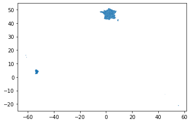

```python
import matplotlib as plt
%matplotlib inline
map_df.plot()
```

```python
pip install descartes
```

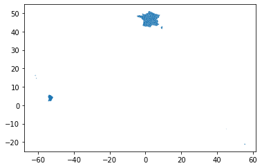

```python
map_df.plot()
```

```python
# map_df[map_df.code_insee.str.contains("\d\d\d")==True]
map_df[map_df.code_insee.str.contains("\d\d\d")]
```

|  | code_insee | nom | nuts3 | wikipedia | geometry |
| --- | --- | --- | --- | --- | --- |
| 96 | 971 | Guadeloupe | FR910 | fr:Guadeloupe | MULTIPOLYGON (((-61.61403 15.83955, -61.61399 ... |
| 97 | 972 | Martinique | FR920 | fr:Martinique | MULTIPOLYGON (((-60.86880 14.39091, -60.86747 ... |
| 98 | 973 | Guyane | FR930 | fr:Guyane | MULTIPOLYGON (((-52.58463 5.28309, -52.58316 5... |
| 99 | 974 | b'La R\xe9union' | FR940 | b'fr:La R\xe9union' | MULTIPOLYGON (((55.77886 -21.36291, 55.77889 -... |
| 100 | 976 | Mayotte | None | fr:Mayotte | MULTIPOLYGON (((45.13667 -13.00398, 45.13859 -... |

```python
# LET'S SEPARATE DOM TOM FROM MAINLAND USING contains and REGEXP syntax
map_df=map_df[map_df.code_insee.str.contains("\d\d\d")==False]

# FILTER SYNTAX FOUND HERE : https://cmdlinetips.com/2018/02/how-to-subset-pandas-dataframe-based-on-values-of-a-column
```

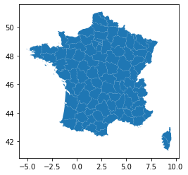

```python
map_df.plot()
```

```python
map_df
```

|  | code_insee | nom | nuts3 | wikipedia | geometry |
| --- | --- | --- | --- | --- | --- |
| 0 | 01 | Ain | FR711 | b'fr:Ain (d\xe9partement)' | POLYGON ((5.25559 45.78459, 5.23987 45.77758, ... |
| 1 | 02 | Aisne | FR221 | b'fr:Aisne (d\xe9partement)' | POLYGON ((3.48175 48.86640, 3.48647 48.85768, ... |
| 2 | 03 | Allier | FR721 | b'fr:Allier (d\xe9partement)' | POLYGON ((2.38613 46.33196, 2.38407 46.33112, ... |
| 3 | 04 | Alpes-de-Haute-Provence | FR821 | fr:Alpes-de-Haute-Provence | POLYGON ((6.66579 43.83120, 6.67673 43.83178, ... |
| 4 | 05 | Hautes-Alpes | FR822 | fr:Hautes-Alpes | POLYGON ((6.24158 44.44686, 6.24411 44.44693, ... |
| ... | ... | ... | ... | ... | ... |
| 91 | 91 | Essonne | FR104 | b'fr:Essonne (d\xe9partement)' | POLYGON ((2.39233 48.33593, 2.39427 48.33263, ... |
| 92 | 92 | Hauts-de-Seine | FR105 | fr:Hauts-de-Seine | POLYGON ((2.31993 48.77075, 2.31588 48.76670, ... |
| 93 | 93 | Seine-Saint-Denis | FR106 | fr:Seine-Saint-Denis | POLYGON ((2.41899 48.84939, 2.41636 48.84924, ... |
| 94 | 94 | Val-de-Marne | FR107 | fr:Val-de-Marne | POLYGON ((2.41450 48.71780, 2.41320 48.71868, ... |
| 95 | 95 | Val-d'Oise | FR108 | fr:Val-d'Oise | POLYGON ((1.79674 49.07196, 1.79991 49.06425, ... |

96 rows × 5 columns

```python
# YOU MUST KNOW REGEXPS
# REGEXP SYNTAX https://www.w3schools.com/python/python_regex.asp
# Pandas contains :
```

```python
# GEOPANDAS MERGE (JOIN)
# https://geopandas.org/mergingdata.html

# Now that we have our shape map containing a dataframe with
# - a column containing polygon definition
# - a column with departments codes
# We need to make a join with our firstname dataframe

prenoms= pd.read_csv("datasets/dpt2018.csv",sep=";")
prenoms
```

|  | sexe | preusuel | annais | dpt | nombre |
| --- | --- | --- | --- | --- | --- |
| 0 | 1 | A | XXXX | XX | 27 |
| 1 | 1 | AADAM | XXXX | XX | 27 |
| 2 | 1 | AADEL | XXXX | XX | 55 |
| 3 | 1 | AADIL | 1983 | 84 | 3 |
| 4 | 1 | AADIL | 1992 | 92 | 3 |
| ... | ... | ... | ... | ... | ... |
| 3624989 | 2 | ÉYA | 2014 | 69 | 3 |
| 3624990 | 2 | ÉYA | XXXX | XX | 23 |
| 3624991 | 2 | ÏNAYA | XXXX | XX | 21 |
| 3624992 | 2 | ÖZGE | XXXX | XX | 30 |
| 3624993 | 2 | ÖZLEM | XXXX | XX | 95 |

3624994 rows × 5 columns

```python
dpt_sum=prenoms.groupby("dpt").nombre.sum()
dpt_sum
```

```
dpt
01      437904
02      842940
03      498369
04      105739
05      126071
        ...
971     640654
972     637827
973     169185
974    1192007
XX     8261688
Name: nombre, Length: 100, dtype: int64
```

```python
type(dpt_sum)
```

```
pandas.core.series.Series
```

```python
# We want a dataframe to do the merging
dpt_sum=dpt_sum.reset_index()
dpt_sum
```

|  | dpt | nombre |
| --- | --- | --- |
| 0 | 01 | 437904 |
| 1 | 02 | 842940 |
| 2 | 03 | 498369 |
| 3 | 04 | 105739 |
| 4 | 05 | 126071 |
| ... | ... | ... |
| 95 | 971 | 640654 |
| 96 | 972 | 637827 |
| 97 | 973 | 169185 |
| 98 | 974 | 1192007 |
| 99 | XX | 8261688 |

100 rows × 2 columns

```python
type(dpt_sum)
```

```
pandas.core.frame.DataFrame
```

```python
# Let's create a new department column with the same name than the column in our shape file
dpt_sum["code_insee"]=dpt_sum.dpt
```

```python
dpt_sum
```

|  | dpt | nombre | code_insee |
| --- | --- | --- | --- |
| 0 | 01 | 437904 | 01 |
| 1 | 02 | 842940 | 02 |
| 2 | 03 | 498369 | 03 |
| 3 | 04 | 105739 | 04 |
| 4 | 05 | 126071 | 05 |
| ... | ... | ... | ... |
| 95 | 971 | 640654 | 971 |
| 96 | 972 | 637827 | 972 |
| 97 | 973 | 169185 | 973 |
| 98 | 974 | 1192007 | 974 |
| 99 | XX | 8261688 | XX |

100 rows × 3 columns

```python
# NOW LET'S MAKE THE MERGE


merged = map_df.merge(dpt_sum, on='code_insee')

merged.head()

merged
```

|  | code_insee | nom | nuts3 | wikipedia | geometry | dpt | nombre |
| --- | --- | --- | --- | --- | --- | --- | --- |
| 0 | 01 | Ain | FR711 | b'fr:Ain (d\xe9partement)' | POLYGON ((5.25559 45.78459, 5.23987 45.77758, ... | 01 | 437904 |
| 1 | 02 | Aisne | FR221 | b'fr:Aisne (d\xe9partement)' | POLYGON ((3.48175 48.86640, 3.48647 48.85768, ... | 02 | 842940 |
| 2 | 03 | Allier | FR721 | b'fr:Allier (d\xe9partement)' | POLYGON ((2.38613 46.33196, 2.38407 46.33112, ... | 03 | 498369 |
| 3 | 04 | Alpes-de-Haute-Provence | FR821 | fr:Alpes-de-Haute-Provence | POLYGON ((6.66579 43.83120, 6.67673 43.83178, ... | 04 | 105739 |
| 4 | 05 | Hautes-Alpes | FR822 | fr:Hautes-Alpes | POLYGON ((6.24158 44.44686, 6.24411 44.44693, ... | 05 | 126071 |
| ... | ... | ... | ... | ... | ... | ... | ... |
| 89 | 91 | Essonne | FR104 | b'fr:Essonne (d\xe9partement)' | POLYGON ((2.39233 48.33593, 2.39427 48.33263, ... | 91 | 572350 |
| 90 | 92 | Hauts-de-Seine | FR105 | fr:Hauts-de-Seine | POLYGON ((2.31993 48.77075, 2.31588 48.76670, ... | 92 | 1153065 |
| 91 | 93 | Seine-Saint-Denis | FR106 | fr:Seine-Saint-Denis | POLYGON ((2.41899 48.84939, 2.41636 48.84924, ... | 93 | 975846 |
| 92 | 94 | Val-de-Marne | FR107 | fr:Val-de-Marne | POLYGON ((2.41450 48.71780, 2.41320 48.71868, ... | 94 | 806129 |
| 93 | 95 | Val-d'Oise | FR108 | fr:Val-d'Oise | POLYGON ((1.79674 49.07196, 1.79991 49.06425, ... | 95 | 673212 |

94 rows × 7 columns

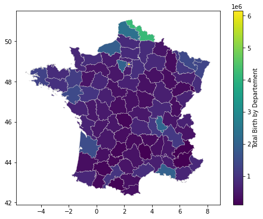

```python
import matplotlib.pyplot as plt
fig, ax = plt.subplots(1, figsize=(8, 6))

merged.plot(column="nombre",   ax=ax, linewidth=0.3,edgecolor="0.8",legend=True,legend_kwds
            ={"label": "Total Birth by Departement"})
```

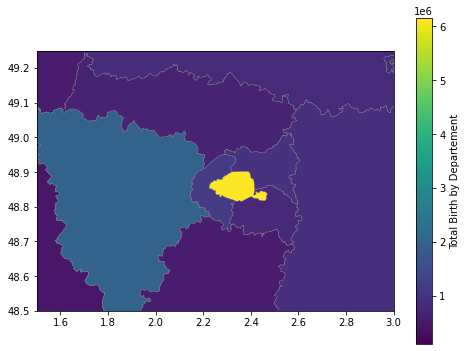

```python
# LET's ZOOM IN AND ADD A LEGEND
fig, ax = plt.subplots(1, figsize=(8, 6))
plt.axis([1.5,3,48.5,49.25])

merged.plot(column="nombre", ax=ax , linewidth=0.3, edgecolor="0.5", legend=True, legend_kwds
            ={"label": "Total Birth by Departement"})
```

```python
# POUR ALLER PLUS LOIN : https://geopandas.org/mapping.html
# https://geopandas.readthedocs.io/en/latest/docs/changelog.html
```

# 3. EXERCICES :

### - Display a choropleth map with Boys/girls total births disparity.

- you must ask yourself what is boys / girls disparity ?
- you must make sure your data is weighted:
  - if you use boys / girls ratio, you don't need to weight your data, because this ratio can be compared among all departement.
  - if you use boys - girls, you should then weight it using total births in the departement, and say for instance : difference between boys and girls births for 1000 births. if you don't do this weighting, your output will be meaningless, because it will mainly express the number of total births of the department.

### - Display a choropleth map with number of girls named Emma born in 2018

### - The same but weighted

( for instance nb of Emma births per thousand births in the dpt OR use dpt population ratio/ total france population) using a dataset with 2018 population for every dpt. the file must contain a department column with the same data as the prenoms dpt column...

SUPERBONUS

- choropleth map for the most innovant departements , population weighted what is innovation ?
- choropleth map for the most trendsetting departements , population weighted what is trendsetting ? we could detect firstname that appear (or come again..) in one or a few departments only, and then grows in other departments.

## Display a choropleth map with Boys/girls total births disparity

```python
genre = prenoms.groupby(["sexe"]).nombre.sum()
boysNumber = genre.iloc[0]
girlsNumber = genre.iloc[1]
print(boysNumber)
print(girlsNumber)
```

```
42888936
42250453
```

```python
dpt_BG = prenoms.groupby(["dpt", "sexe"]).nombre.sum()
dpt_BG
```

```
dpt  sexe
01   1        222361
     2        215543
02   1        428461
     2        414479
03   1        253694
              ...
973  2         77466
974  1        612562
     2        579445
XX   1       3684762
     2       4576926
Name: nombre, Length: 200, dtype: int64
```

```python
# Number of boys for each department
dpt_Boy=prenoms[prenoms.sexe == 1].groupby("dpt").nombre.sum().to_frame()
dpt_Boy
```

| dpt | nombre |
| --- | --- |
| 01 | 222361 |
| 02 | 428461 |
| 03 | 253694 |
| 04 | 55230 |
| 05 | 65182 |
| ... | ... |
| 971 | 338105 |
| 972 | 333358 |
| 973 | 91719 |
| 974 | 612562 |
| XX | 3684762 |

100 rows × 1 columns

```python
dpt_girl=prenoms[prenoms.sexe == 2].groupby("dpt").nombre.sum().to_frame()
dpt_girl
```

| dpt | nombre |
| --- | --- |
| 01 | 215543 |
| 02 | 414479 |
| 03 | 244675 |
| 04 | 50509 |
| 05 | 60889 |
| ... | ... |
| 971 | 302549 |
| 972 | 304469 |
| 973 | 77466 |
| 974 | 579445 |
| XX | 4576926 |

100 rows × 1 columns

```python
dpt_sex = pd.DataFrame()
dpt_sex['Boy_num'] = prenoms[prenoms.sexe == 1].groupby("dpt").nombre.sum()
dpt_sex['Girl_num'] = prenoms[prenoms.sexe == 2].groupby("dpt").nombre.sum()
dpt_sex
```

| dpt | Boy_num | Girl_num |
| --- | --- | --- |
| 01 | 222361 | 215543 |
| 02 | 428461 | 414479 |
| 03 | 253694 | 244675 |
| 04 | 55230 | 50509 |
| 05 | 65182 | 60889 |
| ... | ... | ... |
| 971 | 338105 | 302549 |
| 972 | 333358 | 304469 |
| 973 | 91719 | 77466 |
| 974 | 612562 | 579445 |
| XX | 3684762 | 4576926 |

100 rows × 2 columns

```python
def get_ratio(a,b):
    return a/b
```

```python
dpt_BG = []
dpt_girl2=prenoms[prenoms.sexe == 2].groupby("dpt").nombre.sum()
dpt_Boy2=prenoms[prenoms.sexe == 1].groupby("dpt").nombre.sum()
for i in range(len(dpt_Boy)):
    temp = get_ratio(dpt_Boy2[i],dpt_girl2[i])
    dpt_BG.append(temp)

dpt_BG
```

```
[1.03163173937451,
 1.0337339165554829,
 1.0368611423316645,
 1.0934684907640222,
 1.0705053457931646,
 1.063815200964364,
 1.0266780968709817,
 1.0345433122091252,
 1.0643429867595084,
 1.0608355742539903,
 1.0606115045376048,
 1.0328762288883286,
 1.0466553875480196,
 1.0366587125493643,
 1.0247560809675123,
 1.0557215205536357,
 1.0561189809402105,
 1.040038804127348,
 1.0388210798830118,
 1.0588826911752056,
 1.0536652972330842,
 1.0032036667616604,
 1.019358431721987,
 1.0332160755790905,
 1.0460159226495385,
 1.0659837234299252,
 1.0397855984098914,
 1.0594454652470995,
 1.0046216855235106,
 1.0548841364979338,
 1.0646065580464699,
 1.0642986661920284,
 1.044084579568135,
 1.061506952628945,
 1.0253897351753338,
 1.0393324301171953,
 1.053971937156666,
 1.0485901617445705,
 1.0443768475021158,
 1.0351079171564648,
```

[output cut: 45 more lines]

```
 1.0585908489775493,
 1.0358940195021769,
 1.0159696231386648,
 1.0562223139358922,
 1.0754649827784155,
 1.0862721940942113,
 1.0729482025873538,
 1.0756983721489208,
 1.074075884621619,
 1.0813930120608577,
 1.11752145933386,
 1.0948832229225307,
 1.1839903957865385,
 1.0571529653375213,
 0.8050735362555567]
```

```python
dataset_Final = pd.DataFrame({'ratio':dpt_BG})
dataset_Final
```

|  | ratio |
| --- | --- |
| 0 | 1.031632 |
| 1 | 1.033734 |
| 2 | 1.036861 |
| 3 | 1.093468 |
| 4 | 1.070505 |
| ... | ... |
| 95 | 1.117521 |
| 96 | 1.094883 |
| 97 | 1.183990 |
| 98 | 1.057153 |
| 99 | 0.805074 |

100 rows × 1 columns

```python
dpt_temp=prenoms.groupby("dpt").nombre.sum()
dpt_temp=dpt_temp.reset_index()
dpt_temp
```

|  | dpt | nombre |
| --- | --- | --- |
| 0 | 01 | 437904 |
| 1 | 02 | 842940 |
| 2 | 03 | 498369 |
| 3 | 04 | 105739 |
| 4 | 05 | 126071 |
| 5 | 06 | 809806 |
| 6 | 07 | 354618 |
| 7 | 08 | 447215 |
| 8 | 09 | 156535 |
| 9 | 10 | 380117 |
| 10 | 11 | 355575 |
| 11 | 12 | 403221 |
| 12 | 13 | 1966975 |
| 13 | 14 | 875694 |
| 14 | 15 | 252971 |
| 15 | 16 | 465181 |
| 16 | 17 | 680598 |
| 17 | 18 | 370112 |
| 18 | 19 | 333912 |
| 19 | 20 | 311161 |
| 20 | 21 | 622353 |
| 21 | 22 | 843509 |
| 22 | 23 | 181298 |
| 23 | 24 | 487246 |
| 24 | 25 | 689002 |
| 25 | 26 | 470910 |
| 26 | 27 | 558273 |
| 27 | 28 | 474107 |
| 28 | 29 | 1310770 |
| 29 | 30 | 607171 |
| ... | ... | ... |
| 70 | 71 | 790059 |
| 71 | 72 | 758189 |
| 72 | 73 | 421167 |
| 73 | 74 | 653475 |
| 74 | 75 | 6160048 |
| 75 | 76 | 1891236 |
| 76 | 77 | 923844 |
| 77 | 78 | 1978581 |
| 78 | 79 | 498531 |
| 79 | 80 | 836340 |
| 80 | 81 | 423366 |
| 81 | 82 | 220661 |
| 82 | 83 | 699417 |
| 83 | 84 | 554743 |
| 84 | 85 | 695032 |
| 85 | 86 | 518347 |
| 86 | 87 | 479791 |
| 87 | 88 | 629674 |
| 88 | 89 | 373667 |
| 89 | 90 | 180773 |
| 90 | 91 | 572350 |
| 91 | 92 | 1153065 |
| 92 | 93 | 975846 |
| 93 | 94 | 806129 |
| 94 | 95 | 673212 |
| 95 | 971 | 640654 |
| 96 | 972 | 637827 |
| 97 | 973 | 169185 |
| 98 | 974 | 1192007 |
| 99 | XX | 8261688 |

100 rows × 2 columns

```python
### OU
dpt_sex['ratio'] = get_ratio(dpt_sex['Boy_num'],dpt_sex['Girl_num'])
dpt_sex
```

[output not shown]

```python
dpt_sex = dpt_sex.reset_index()
dpt_sex
```

|  | dpt | Boy_num | Girl_num | ratio |
| --- | --- | --- | --- | --- |
| 0 | 01 | 222361 | 215543 | 1.031632 |
| 1 | 02 | 428461 | 414479 | 1.033734 |
| 2 | 03 | 253694 | 244675 | 1.036861 |
| 3 | 04 | 55230 | 50509 | 1.093468 |
| 4 | 05 | 65182 | 60889 | 1.070505 |
| ... | ... | ... | ... | ... |
| 95 | 971 | 338105 | 302549 | 1.117521 |
| 96 | 972 | 333358 | 304469 | 1.094883 |
| 97 | 973 | 91719 | 77466 | 1.183990 |
| 98 | 974 | 612562 | 579445 | 1.057153 |
| 99 | XX | 3684762 | 4576926 | 0.805074 |

100 rows × 4 columns

```python
dpt_sex["code_insee"]=dpt_sex.dpt
dpt_sex
```

|  | dpt | Boy_num | Girl_num | ratio | code_insee |
| --- | --- | --- | --- | --- | --- |
| 0 | 01 | 222361 | 215543 | 1.031632 | 01 |
| 1 | 02 | 428461 | 414479 | 1.033734 | 02 |
| 2 | 03 | 253694 | 244675 | 1.036861 | 03 |
| 3 | 04 | 55230 | 50509 | 1.093468 | 04 |
| 4 | 05 | 65182 | 60889 | 1.070505 | 05 |
| ... | ... | ... | ... | ... | ... |
| 95 | 971 | 338105 | 302549 | 1.117521 | 971 |
| 96 | 972 | 333358 | 304469 | 1.094883 | 972 |
| 97 | 973 | 91719 | 77466 | 1.183990 | 973 |
| 98 | 974 | 612562 | 579445 | 1.057153 | 974 |
| 99 | XX | 3684762 | 4576926 | 0.805074 | XX |

100 rows × 5 columns

```python
merged_BG = map_df.merge(dpt_sex, on='code_insee')

merged_BG.head()

merged_BG
```

|  | code_insee | nom | nuts3 | wikipedia | geometry | dpt | Boy_num | Girl_num | ratio |
| --- | --- | --- | --- | --- | --- | --- | --- | --- | --- |
| 0 | 01 | Ain | FR711 | b'fr:Ain (d\xe9partement)' | POLYGON ((5.25559 45.78459, 5.23987 45.77758, ... | 01 | 222361 | 215543 | 1.031632 |
| 1 | 02 | Aisne | FR221 | b'fr:Aisne (d\xe9partement)' | POLYGON ((3.48175 48.86640, 3.48647 48.85768, ... | 02 | 428461 | 414479 | 1.033734 |
| 2 | 03 | Allier | FR721 | b'fr:Allier (d\xe9partement)' | POLYGON ((2.38613 46.33196, 2.38407 46.33112, ... | 03 | 253694 | 244675 | 1.036861 |
| 3 | 04 | Alpes-de-Haute-Provence | FR821 | fr:Alpes-de-Haute-Provence | POLYGON ((6.66579 43.83120, 6.67673 43.83178, ... | 04 | 55230 | 50509 | 1.093468 |
| 4 | 05 | Hautes-Alpes | FR822 | fr:Hautes-Alpes | POLYGON ((6.24158 44.44686, 6.24411 44.44693, ... | 05 | 65182 | 60889 | 1.070505 |
| ... | ... | ... | ... | ... | ... | ... | ... | ... | ... |
| 89 | 91 | Essonne | FR104 | b'fr:Essonne (d\xe9partement)' | POLYGON ((2.39233 48.33593, 2.39427 48.33263, ... | 91 | 298009 | 274341 | 1.086272 |
| 90 | 92 | Hauts-de-Seine | FR105 | fr:Hauts-de-Seine | POLYGON ((2.31993 48.77075, 2.31588 48.76670, ... | 92 | 596821 | 556244 | 1.072948 |
| 91 | 93 | Seine-Saint-Denis | FR106 | fr:Seine-Saint-Denis | POLYGON ((2.41899 48.84939, 2.41636 48.84924, ... | 93 | 505717 | 470129 | 1.075698 |
| 92 | 94 | Val-de-Marne | FR107 | fr:Val-de-Marne | POLYGON ((2.41450 48.71780, 2.41320 48.71868, ... | 94 | 417460 | 388669 | 1.074076 |
| 93 | 95 | Val-d'Oise | FR108 | fr:Val-d'Oise | POLYGON ((1.79674 49.07196, 1.79991 49.06425, ... | 95 | 349769 | 323443 | 1.081393 |

94 rows × 9 columns

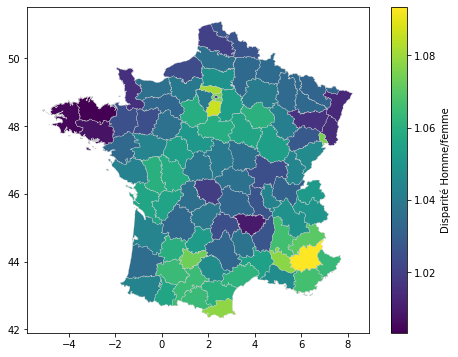

```python
import matplotlib.pyplot as plt
fig2, ax2 = plt.subplots(1, figsize=(8, 6))

merged_BG.plot(column="ratio",   ax=ax2, linewidth=0.3,edgecolor="0.8",legend=True,legend_kwds
            ={"label": "Disparité Homme/femme"})
```

## Display a choropleth map with number of girls named Emma born in 2018

```python
dataset_emma = prenoms[(prenoms['annais'] == '2018') & (prenoms['preusuel'] == 'EMMA')].groupby('dpt').nombre.sum()
dataset_emma = dataset_emma.reset_index()
dataset_emma
```

|  | dpt | nombre |
| --- | --- | --- |
| 0 | 01 | 37 |
| 1 | 02 | 38 |
| 2 | 03 | 28 |
| 3 | 04 | 6 |
| 4 | 05 | 10 |
| ... | ... | ... |
| 93 | 95 | 79 |
| 94 | 971 | 17 |
| 95 | 972 | 11 |
| 96 | 973 | 11 |
| 97 | 974 | 43 |

98 rows × 2 columns

```python
dataset_emma["code_insee"]=dpt_sum.dpt
dataset_emma
```

|  | dpt | nombre | code_insee |
| --- | --- | --- | --- |
| 0 | 01 | 37 | 01 |
| 1 | 02 | 38 | 02 |
| 2 | 03 | 28 | 03 |
| 3 | 04 | 6 | 04 |
| 4 | 05 | 10 | 05 |
| ... | ... | ... | ... |
| 93 | 95 | 79 | 94 |
| 94 | 971 | 17 | 95 |
| 95 | 972 | 11 | 971 |
| 96 | 973 | 11 | 972 |
| 97 | 974 | 43 | 973 |

98 rows × 3 columns

```python
merged_emma = map_df.merge(dataset_emma, on='code_insee')

merged_emma.head()

merged_emma
```

|  | code_insee | nom | nuts3 | wikipedia | geometry | dpt | nombre |
| --- | --- | --- | --- | --- | --- | --- | --- |
| 0 | 01 | Ain | FR711 | b'fr:Ain (d\xe9partement)' | POLYGON ((5.25559 45.78459, 5.23987 45.77758, ... | 01 | 37 |
| 1 | 02 | Aisne | FR221 | b'fr:Aisne (d\xe9partement)' | POLYGON ((3.48175 48.86640, 3.48647 48.85768, ... | 02 | 38 |
| 2 | 03 | Allier | FR721 | b'fr:Allier (d\xe9partement)' | POLYGON ((2.38613 46.33196, 2.38407 46.33112, ... | 03 | 28 |
| 3 | 04 | Alpes-de-Haute-Provence | FR821 | fr:Alpes-de-Haute-Provence | POLYGON ((6.66579 43.83120, 6.67673 43.83178, ... | 04 | 6 |
| 4 | 05 | Hautes-Alpes | FR822 | fr:Hautes-Alpes | POLYGON ((6.24158 44.44686, 6.24411 44.44693, ... | 05 | 10 |
| ... | ... | ... | ... | ... | ... | ... | ... |
| 89 | 91 | Essonne | FR104 | b'fr:Essonne (d\xe9partement)' | POLYGON ((2.39233 48.33593, 2.39427 48.33263, ... | 92 | 142 |
| 90 | 92 | Hauts-de-Seine | FR105 | fr:Hauts-de-Seine | POLYGON ((2.31993 48.77075, 2.31588 48.76670, ... | 93 | 48 |
| 91 | 93 | Seine-Saint-Denis | FR106 | fr:Seine-Saint-Denis | POLYGON ((2.41899 48.84939, 2.41636 48.84924, ... | 94 | 102 |
| 92 | 94 | Val-de-Marne | FR107 | fr:Val-de-Marne | POLYGON ((2.41450 48.71780, 2.41320 48.71868, ... | 95 | 79 |
| 93 | 95 | Val-d'Oise | FR108 | fr:Val-d'Oise | POLYGON ((1.79674 49.07196, 1.79991 49.06425, ... | 971 | 17 |

94 rows × 7 columns

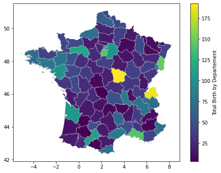

```python
import matplotlib.pyplot as plt
fig2, ax2 = plt.subplots(1, figsize=(8, 6))

merged_emma.plot(column="nombre",   ax=ax2, linewidth=0.3,edgecolor="0.8",legend=True,legend_kwds
            ={"label": "Total Birth by Departement"})
```

## The same but weighted

( for instance nb of Emma births per thousand births in the dpt OR use dpt population ratio/ total france population) using a dataset with 2018 population for every dpt. the file must contain a department column with the same data as the prenoms dpt column...

```python
dpt_pop = prenoms[prenoms.annais == '2018'].groupby('dpt').nombre.sum().to_frame()
dpt_pop
```

| dpt | nombre |
| --- | --- |
| 01 | 2493 |
| 02 | 3296 |
| 03 | 1830 |
| 04 | 371 |
| 05 | 596 |
| ... | ... |
| 95 | 15195 |
| 971 | 2561 |
| 972 | 2205 |
| 973 | 5389 |
| 974 | 10488 |

99 rows × 1 columns

```python
dpt_pop = dpt_pop.reset_index()
dpt_weight = dpt_pop.merge(dataset_emma, on='dpt')
dpt_weight
```

|  | dpt | nombre_x | nombre_y | code_insee |
| --- | --- | --- | --- | --- |
| 0 | 01 | 2493 | 37 | 01 |
| 1 | 02 | 3296 | 38 | 02 |
| 2 | 03 | 1830 | 28 | 03 |
| 3 | 04 | 371 | 6 | 04 |
| 4 | 05 | 596 | 10 | 05 |
| ... | ... | ... | ... | ... |
| 93 | 95 | 15195 | 79 | 94 |
| 94 | 971 | 2561 | 17 | 95 |
| 95 | 972 | 2205 | 11 | 971 |
| 96 | 973 | 5389 | 11 | 972 |
| 97 | 974 | 10488 | 43 | 973 |

98 rows × 4 columns

```python
dpt_weight['ratio'] = dpt_weight['nombre_y'] / dpt_weight['nombre_x']
dpt_weight
```

|  | dpt | nombre_x | nombre_y | code_insee | ratio |
| --- | --- | --- | --- | --- | --- |
| 0 | 01 | 2493 | 37 | 01 | 0.014842 |
| 1 | 02 | 3296 | 38 | 02 | 0.011529 |
| 2 | 03 | 1830 | 28 | 03 | 0.015301 |
| 3 | 04 | 371 | 6 | 04 | 0.016173 |
| 4 | 05 | 596 | 10 | 05 | 0.016779 |
| ... | ... | ... | ... | ... | ... |
| 93 | 95 | 15195 | 79 | 94 | 0.005199 |
| 94 | 971 | 2561 | 17 | 95 | 0.006638 |
| 95 | 972 | 2205 | 11 | 971 | 0.004989 |
| 96 | 973 | 5389 | 11 | 972 | 0.002041 |
| 97 | 974 | 10488 | 43 | 973 | 0.004100 |

98 rows × 5 columns

```python
merged_weight = map_df.merge(dpt_weight, on='code_insee')

merged_weight.head()

merged_weight
```

|  | code_insee | nom | nuts3 | wikipedia | geometry | dpt | nombre_x | nombre_y | ratio |
| --- | --- | --- | --- | --- | --- | --- | --- | --- | --- |
| 0 | 01 | Ain | FR711 | b'fr:Ain (d\xe9partement)' | POLYGON ((5.25559 45.78459, 5.23987 45.77758, ... | 01 | 2493 | 37 | 0.014842 |
| 1 | 02 | Aisne | FR221 | b'fr:Aisne (d\xe9partement)' | POLYGON ((3.48175 48.86640, 3.48647 48.85768, ... | 02 | 3296 | 38 | 0.011529 |
| 2 | 03 | Allier | FR721 | b'fr:Allier (d\xe9partement)' | POLYGON ((2.38613 46.33196, 2.38407 46.33112, ... | 03 | 1830 | 28 | 0.015301 |
| 3 | 04 | Alpes-de-Haute-Provence | FR821 | fr:Alpes-de-Haute-Provence | POLYGON ((6.66579 43.83120, 6.67673 43.83178, ... | 04 | 371 | 6 | 0.016173 |
| 4 | 05 | Hautes-Alpes | FR822 | fr:Hautes-Alpes | POLYGON ((6.24158 44.44686, 6.24411 44.44693, ... | 05 | 596 | 10 | 0.016779 |
| ... | ... | ... | ... | ... | ... | ... | ... | ... | ... |
| 89 | 91 | Essonne | FR104 | b'fr:Essonne (d\xe9partement)' | POLYGON ((2.39233 48.33593, 2.39427 48.33263, ... | 92 | 21568 | 142 | 0.006584 |
| 90 | 92 | Hauts-de-Seine | FR105 | fr:Hauts-de-Seine | POLYGON ((2.31993 48.77075, 2.31588 48.76670, ... | 93 | 19328 | 48 | 0.002483 |
| 91 | 93 | Seine-Saint-Denis | FR106 | fr:Seine-Saint-Denis | POLYGON ((2.41899 48.84939, 2.41636 48.84924, ... | 94 | 15475 | 102 | 0.006591 |
| 92 | 94 | Val-de-Marne | FR107 | fr:Val-de-Marne | POLYGON ((2.41450 48.71780, 2.41320 48.71868, ... | 95 | 15195 | 79 | 0.005199 |
| 93 | 95 | Val-d'Oise | FR108 | fr:Val-d'Oise | POLYGON ((1.79674 49.07196, 1.79991 49.06425, ... | 971 | 2561 | 17 | 0.006638 |

94 rows × 9 columns

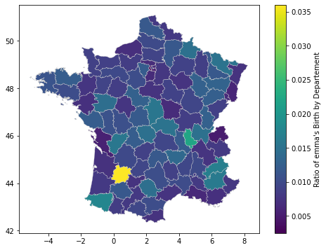

```python
import matplotlib.pyplot as plt
fig2, ax2 = plt.subplots(1, figsize=(8, 6))

merged_weight.plot(column="ratio",   ax=ax2, linewidth=0.3,edgecolor="0.8",legend=True,legend_kwds
            ={"label": "Ratio of emma's Birth by Departement"})
```